# Marine Ecological Modelling Global Climate Change

Jorge Assis, PhD // Centre of Marine Sciences, University of Algarve

## Hyperparameter selection

## Data-driven hyperparameter selection [MaxEnt]

Proper hyperparameter selection allows to develop model with higher potential for transferability.

```
## [1] "All packages are correctly installed and loaded"
```

```r
# read records
presences <- read.csv("Data/dataBases/Paramuricea_clavata.csv", sep = ";")
presences <- presences[, c("Lon", "Lat")]

# load layers of ocean temperatures, oxygen and productivity
envCond <- load_layers(c("BO2_tempmin_bdmean", "BO2_tempmax_bdmean", "BO2_dissoxmean_bdmean",
    "BO2_ppmean_bdmean"))

# crop layers to the European extent
europeanExtent <- extent(-15, 40, 25, 50)
envCond <- crop(envCond, europeanExtent)
```

S8 // Data-driven hyperparameter and variable selection

```r
# generate background information
background <- backgroundInformation(envCond, n = 10000)

# extract environmental values and make a data.frame with PA information
modelData <- prepareModelData(presences, background, envCond)

# fit a Maxent model to the dataset with threshold feature and no regularization
model <- train("Maxnet", modelData, fc = "t", folds = NULL)
```

S8 // Data-driven hyperparameter and variable selection

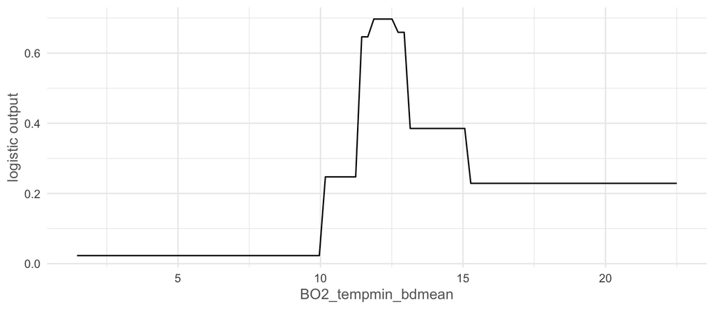

```r
# inspect the effect of one variable
plotResponse(model, var = "BO2_tempmin_bdmean", type = "logistic", color = "Black")
```

S8 // Data-driven hyperparameter and variable selection

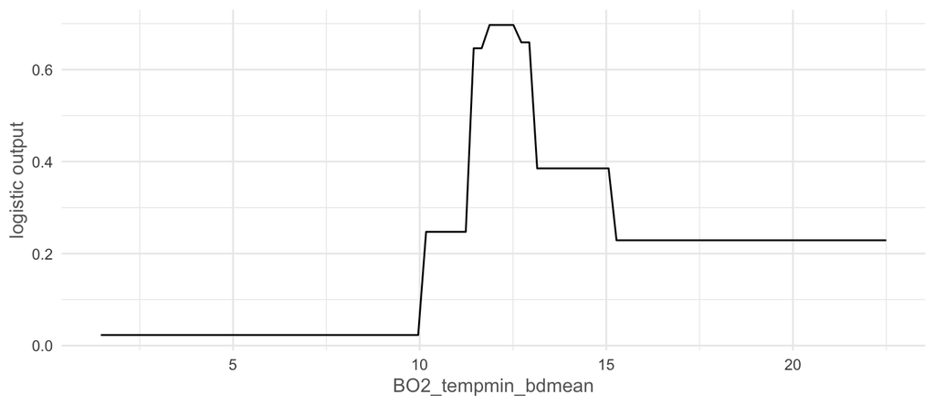

```r
# fit a Maxent model with threshold feature and different regularization steps (β
# multiplier)
model <- train("Maxnet", modelData, reg = 1, fc = "t", folds = NULL)

# inspect the effect of one variable
plotResponse(model, var = "BO2_tempmin_bdmean", type = "logistic", color = "Black")
```

S8 // Data-driven hyperparameter and variable selection

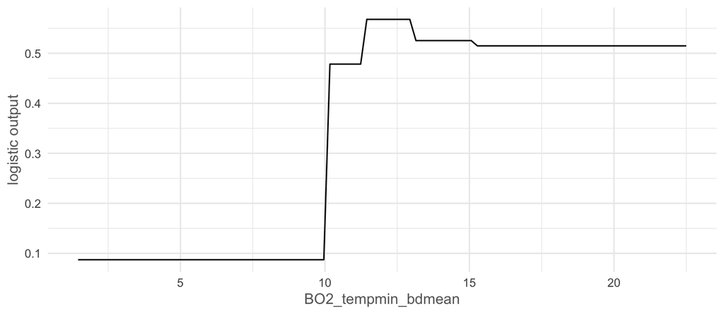

```r
# fit a Maxent model with threshold feature and different regularization steps (β
# multiplier)
model <- train("Maxnet", modelData, reg = 5, fc = "t", folds = NULL)

# inspect the effect of one variable
plotResponse(model, var = "BO2_tempmin_bdmean", type = "logistic", color = "Black")
```

S8 // Data-driven hyperparameter and variable selection

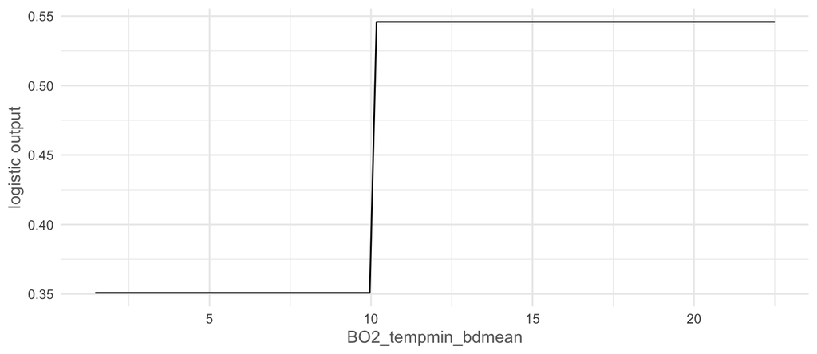

```r
# fit a Maxent model with threshold feature and different regularization steps (β
# multiplier)
model <- train("Maxnet", modelData, reg = 25, fc = "t", folds = NULL)

# inspect the effect of one variable
plotResponse(model, var = "BO2_tempmin_bdmean", type = "logistic", color = "Black")
```

S8 // Data-driven hyperparameter and variable selection

```r
# prepare data splitting for cross-validation
folds <- getBlocks(modelData)
```

```r
# train a model with threshold feature
model <- train("Maxnet", modelData, folds = folds, fc = "t")

# given a set of possible hyperparameter values (regularization)
h <- list(reg = seq(1, 10, 1))
```

```r
# train models with all the possible combinations of hyperparameters
exp1 <- gridSearch(model, hypers = h, metric = "auc")
```

S8 // Data-driven hyperparameter and variable selection

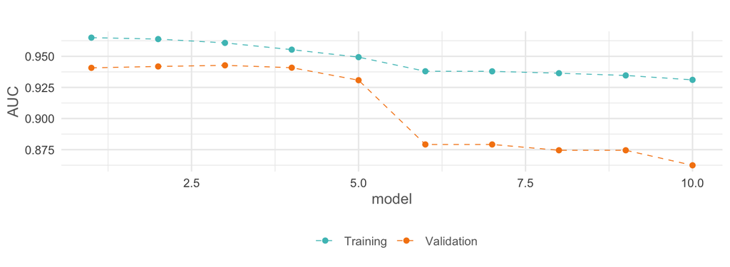

```r
plot(exp1)
```

```r
head(exp1@results)
```

```
##   fc reg train_AUC  test_AUC   diff_AUC
## 1  t   1 0.9649906 0.9407318 0.02425885
## 2  t   2 0.9638362 0.9418465 0.02198969
## 3  t   3 0.9607841 0.9427426 0.01804150
## 4  t   4 0.9553407 0.9408511 0.01448964
## 5  t   5 0.9493348 0.9307995 0.01853536
## 6  t   6 0.9379866 0.8791755 0.05881106
```

S8 // Data-driven hyperparameter and variable selection

```r
# get the best hyperparameter value and fit a model to the dataset
which.max(exp1@results$test_AUC)
```

```
## [1] 3
```

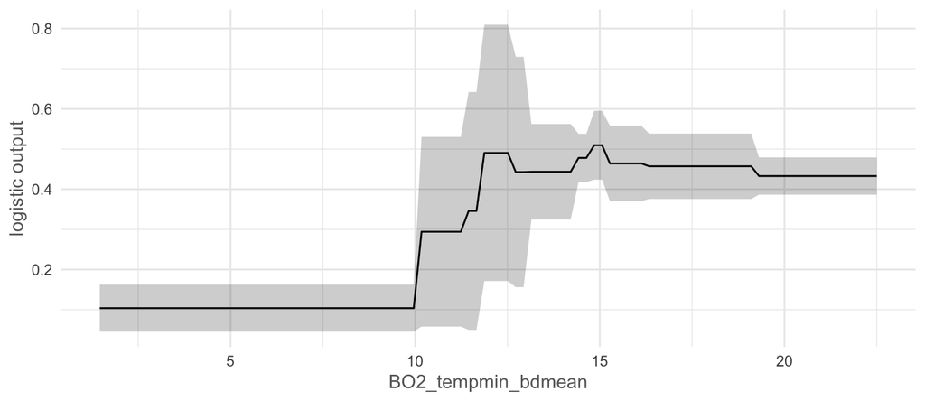

```r
model <- train("Maxnet", modelData, folds = folds, fc = "t", reg = which.max(exp1@results$test_AUC))
plotResponse(model, var = "BO2_tempmin_bdmean", type = "logistic", color = "Black")
```

S8 // Data-driven hyperparameter and variable selection

### Challenge 8.1

The main objective of this challenge is to **fit** a MaxEnt model and **tune** proper hyperparameter selection.

**Packages, data and functions to accomplish the challenge:**

source(“sourceFunctions.R”)  
list_layers(datasets = “Bio-ORACLE”)  
read.csv(path)  
crop(object)  
backgroundInformation(object)  
prepareModelData(object)  
getBlocks(object)  
train(object)  
getAUC(object)  
gridSearch(object)

S8 // Data-driven hyperparameter and variable selection

## Data-driven hyperparameter selection [BRT]

```r
# read records
presences <- read.csv("Data/dataBases/Paramuricea_clavata.csv", sep = ";")
presences <- presences[, c("Lon", "Lat")]

# load layers of ocean temperatures, oxygen and productivity
envCond <- load_layers(c("BO2_tempmin_bdmean", "BO2_tempmax_bdmean", "BO2_dissoxmean_bdmean",
    "BO2_ppmean_bdmean"))

# crop layers to the European extent
europeanExtent <- extent(-15, 40, 25, 50)
envCond <- crop(envCond, europeanExtent)

# generate pseudo absences
absences <- pseudoAbsences(envCond, presences, n = 10000)

# extract environmental values and make a data.frame with PA information
modelData <- prepareModelData(presences, absences, envCond)
```

S8 // Data-driven hyperparameter and variable selection

```r
# prepare data splitting for cross-validation
folds <- getBlocks(modelData)

# train a BRT model
model <- train("BRT", modelData, folds = folds)

# given a set of possible hyperparameter values (interaction.depth or tree complexity)
h <- list(interaction.depth = c(1, 2, 3, 4, 5))

# train models with all the possible combinations of hyperparameters
exp1 <- gridSearch(model, hypers = h, metric = "auc")
```

S8 // Data-driven hyperparameter and variable selection

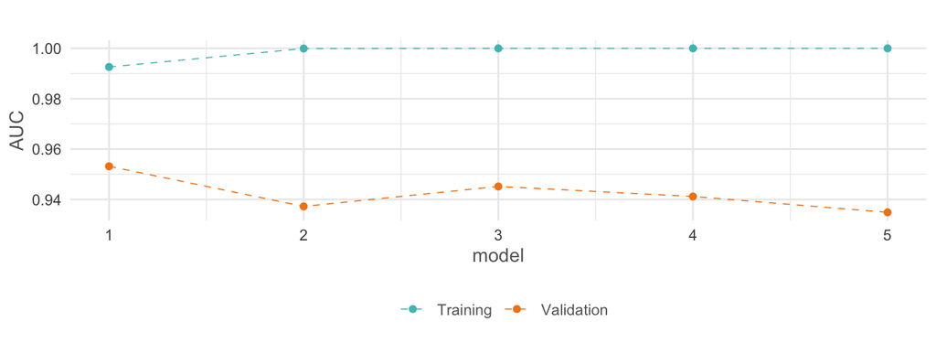

```r
plot(exp1)
```

```r
# get the best hyperparameter value and fit a BRT model to the dataset
which.max(exp1@results$test_AUC)
```

```
## [1] 1
```

```r
model <- train("BRT", modelData, interaction.depth = which.max(exp1@results$test_AUC), folds = folds)
```

S8 // Data-driven hyperparameter and variable selection

## Variable selection

## Data-driven variable selection

In cases which a model has some environmental variables ranked with very low contribution and one may want to remove them in order to reduce the complexity of the model.

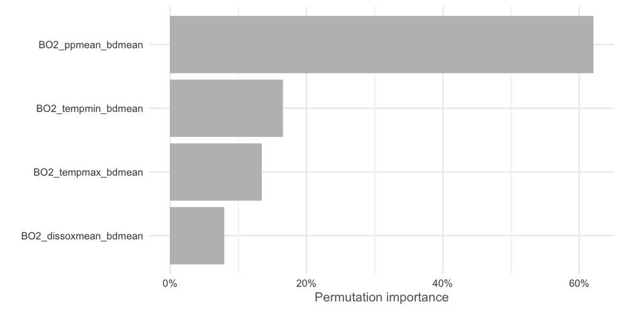

```r
# determine relative variable contribution and performance as AUC
viModel <- varImp(model, permut = 5)
plotVarImp(viModel)
```

S8 // Data-driven hyperparameter and variable selection

```r
getAUC(model, test = TRUE)
```

```
## [1] 0.9537773
```

```r
# reduce model complexity by dropping one variable at a time then remove all variables that
# have a permutation importance lower than 5%.
reducedModel <- reduceVar(model, th = 5, metric = "auc", permut = 5)

# determine relative variable contribution and performance as AUC of the reduced model
viModel <- varImp(reducedModel, permut = 5)
```

S8 // Data-driven hyperparameter and variable selection

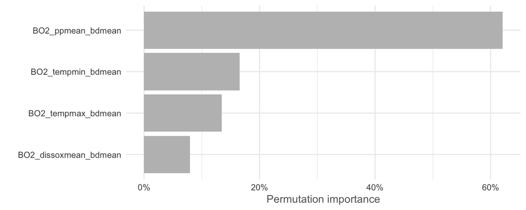

```r
plotVarImp(viModel)
```

```r
getAUC(model, test = TRUE)
```

```
## [1] 0.9537773
```

```r
getAUC(reducedModel, test = TRUE)
```

```
## [1] 0.9537773
```

S8 // Data-driven hyperparameter and variable selection

### Challenge 8.2

The main objective of this challenge is to **fit** a MaxEnt model and **remove variables with low importance**.

**Packages, data and functions to accomplish the challenge:**

source(“sourceFunctions.R”)  
list_layers(datasets = “Bio-ORACLE”)  
read.csv(path)  
crop(object)  
backgroundInformation(object)  
prepareModelData(object)  
getBlocks(object)  
train(object)  
getAUC(object)  
gridSearch(object)  
reduceVar(object)

S8 // Data-driven hyperparameter and variable selection

## Monotonicity

## Monotonicity constrains in ecological modelling

```
## [1] "All packages are correctly installed and loaded"
```

```r
# read records
presences <- read.csv("Data/dataBases/Paramuricea_clavata.csv", sep = ";")
presences <- presences[, c("Lon", "Lat")]

# load layers of ocean temperatures, oxygen and productivity
envCond <- load_layers(c("BO2_tempmin_bdmean", "BO2_tempmax_bdmean", "BO2_dissoxmean_bdmean",
    "BO2_ppmean_bdmean"))

# crop layers to the European extent
europeanExtent <- extent(-15, 40, 25, 50)
envCond <- crop(envCond, europeanExtent)

# generate pseudo absences
absences <- pseudoAbsences(envCond, presences, n = 10000)
```

S8 // Data-driven hyperparameter and variable selection

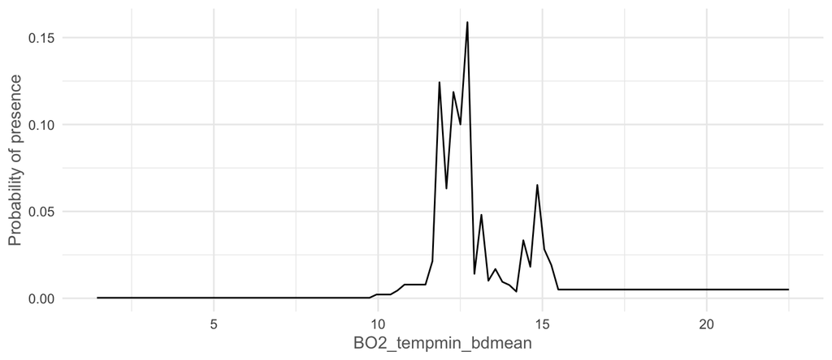

```r
# extract environmental values and make a data.frame with PA information
modelData <- prepareModelData(presences, absences, envCond)

# fit a BRT model to the dataset
model <- train("BRT", modelData, folds = NULL)

plotResponse(model, var = "BO2_tempmin_bdmean", color = "Black")
```

S8 // Data-driven hyperparameter and variable selection

```r
# prepare a dataset of monotonicity constrains 0 for no monotonicity effect -1 for negative
# monotonicity effect +1 for positive monotonicity effect
monotonicity <- data.frame(BO2_tempmin_bdmean = +1, BO2_tempmax_bdmean = -1, BO2_dissoxmean_bdmean = +1,
    BO2_ppmean_bdmean = +1)

head(monotonicity)
```

```
##   BO2_tempmin_bdmean BO2_tempmax_bdmean BO2_dissoxmean_bdmean BO2_ppmean_bdmean
## 1                  1                 -1                     1                 1
```

S8 // Data-driven hyperparameter and variable selection

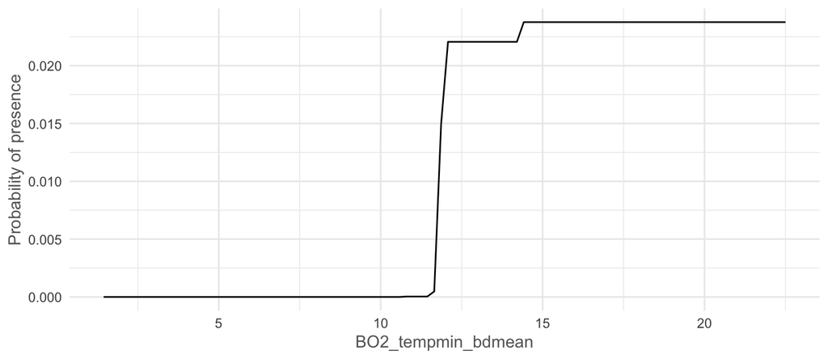

```r
# fit a BRT model to the dataset with monotonicity constrains
model <- train("BRT", modelData, folds = NULL)

# inspect the effect of one variable
plotResponse(model, var = "BO2_tempmin_bdmean", color = "Black")
```

S8 // Data-driven hyperparameter and variable selection

## References

Global change impacts on biodiversity. Available at: https://damariszurell.github.io/HU-GCIB

Copyright (c) Earth Lab. Available at: https://www.earthdatascience.org.

Open Science for Synthesis: Gulf Research Program Workshop. Available at: https://github.com/NCEAS/oss-lessons

Gimond, M. (2019) Intro to GIS and Spatial Analysis. Available at: https://mgimond.github.io/Spatial/